# Master of Operational Research-Python Programming Practicals

## NAME: MEDNI ASWAL

### ROLL NO. : 20/1658

### SOUTH CAMPUS

#### Q1. Write a program to enter name and display as “Hello, Name”.

```python
name=input("What's your name ? \n")
print("Hello,", name)
```

```
What's your name ?
Medni
Hello, Medni
```

#### Q2. Write a menu driven program to enter two numbers and print the arithmetic operations like a) + b) – c) * d) / e) // f) %.

```python
def arithmetic_operations():
    a=int(input("Enter first number :\t"))
    b=int(input("Enter second number :\t"))
    print(" 1- Addition \n 2- Substraction \n 3- Multiplication \n 4- Division \n 5- Floor division \n 6- Modulus")
    operation=int(input("Enter the operation you want to perform :\t"))
    if operation ==1:
        print("You chose Addition -", a+b)
    elif operation==2:
        print("You chose Substraction -", a-b)
    elif operation==3:
        print("You chose Multiplication -",a*b)
    elif operation==4:
        print("You chose Division -",a/b)
    elif operation==5:
        print("You chose Floor Division -",a//b)
    elif operation==6:
        print("You chose Modulus -",a%b)
    else:
        print("INVALID OPERATION")
arithmetic_operations()
```

```
Enter first number :	3
Enter second number :	4
 1- Addition
 2- Substraction
 3- Multiplication
 4- Division
 5- Floor division
 6- Modulus
Enter the operation you want to perform :	3
You chose Multiplication - 12
```

#### Q3. To compute the roots of a quadratic equation.

```python
import cmath
def rootsofquad():
    a=int(input("Enter the coeffcient of x^2 :\t"))
    b=int(input("Enter the coeffcient of x :\t"))
    c=int(input("Enter the value of constant term :\t"))
    d=b*b-4*a*c
    root1=(-b+cmath.sqrt(d)/2*a)
    root2=(-b-cmath.sqrt(d)/2*a)
    print('The roots of the given quadratic equations are ', root1,'and',root2,'.')
rootsofquad()
```

```
Enter the coeffcient of x^2 :	1
Enter the coeffcient of x :	2
Enter the value of constant term :	1
The roots of the given quadratic equations are  (-2+0j) and (-2+0j) .
```

#### Q4.Write a menu driven Program to reverse the entered numbers and print the sum of digits entered.

```python
a=int(input("Enter a number with more than 2 digits :\t"))
print(" 1- Reverse the digits \n 2- Sum of the digits entered ")
b=int(input("Choose an operation you want to perform :\t"))
if b==1:
    rev=0
    while(a>0):
        d=a%10
        rev=rev*10+d
        a=a//10
    print("The reverse of the entered number is",rev)
elif b==2:
    sum=0
    while(a>0):
        d=a%10
        sum=sum+d
        a=a//10
    print("The sum of the digits is", sum)
else:
    print("INVALID, Please check the number you have entered.")
```

```
Enter a number with more than 2 digits :	112
 1- Reverse the digits
 2- Sum of the digits entered
Choose an operation you want to perform :	1
The reverse of the entered number is 211
```

#### Q5.Write a menu driven Program to enter the number and print whether the number is a) odd or even b)prime

```python
n=int(input("Enter a number :\t"))
print(" 1) Odd or Even \n 2) Prime")
c=int(input("Choose an operation you want to perform :\t"))
if c==1:
    r=n%2
    if r==0:
        print("EVEN")
    else:
        print("ODD")
elif c==2:
    if n==2:
        print("The number is prime.")
    elif n>1:
        for i in range(2,n):
            if n%i==0:
                print("The numbers is not Prime.")
                break
            else:
                print("The number is prime")
                break
    else:
        print("The number is not prime.")
else:
    print("Invalid")
```

```
Enter a number :	1
 1) Odd or Even
 2) Prime
Choose an operation you want to perform :	2
The number is not prime.
```

#### Q6. Program to find maximum out of entered 3 numbers.

```python
a=int(input("Enter first number :\t"))
b=int(input("Enter second number :\t"))
c=int(input("Enter third number :\t"))
if a>b and a>c:
    print("The maximum number is,", a)
elif b>a and b>c:
    print("The maximum number is,", b)
else:
    print("The maximum out of entered 3 numbers is,", c)
```

```
Enter first number :	22
Enter second number :	35
Enter third number :	6
The maximum number is, 35
```

#### Q7. Write a program to display ASCII code of a character and vice versa.

```python
x=input("Enter a character :\t")
print(ord(x))
y=int(input("Enter an ASCII value :\t "))
print(chr(y))
```

```
Enter a character :	y
121
Enter an ASCII value :	 121
y
```

#### Q8.Write a Program to check if the entered number is Armstrong or not.

```python
n=int(input("Enter a number :\t"))
o=len(str(n))
s=0
x=n
while x>0:
    d=x%10
    s+=d**o
    x//=10
if n==s:
    print("The entered numer is an Armstrong number.")
else:
    print("The entered number is not an Armstrong number.")
```

```
Enter a number :	153
The entered numer is an Armstrong number.
```

#### Q9. Write a Program to find factorial of the entered number using recursion.

```python
def fact(n):
    if(n==0 or n==1):
        return 1
    else:
        return n*fact(n-1)
n=int(input("Enter a number :\t"))
print("The factorial of",n,"is",fact(n),'.')
```

```
Enter a number :	5
The factorial of 5 is 120 .
```

#### Q10. Write a Program to enter the number of terms and to print the Fibonacci Series.

```python
def fibonacci(n):
    if n<=0:
        print("Enter a value greater than 0")
    elif(n==1):
        return 0
    elif(n==2):
        return 1
    else:
        return fibonacci(n-1)+fibonacci(n-2)
n=int(input("Enter a number:\t"))
print("The required fibonacci series is",fibonacci(n))
```

```
Enter a number:	5
The required fibonacci series is 3
```

#### Q11.Write a Program to enter the numbers and to print greatest number using loop.

```python
tot=int(input("Enter the total no. of elements:\t"))
n=int(input("                 Enter a number:\t"))
largest=n
for i in range(1,tot):
    n1=int(input("      Enter another element:\t"))
    if(n1>largest):
        largest=n1
print("The largest no. is",largest)
```

```
Enter the total no. of elements:	3
                 Enter a number:	2
      Enter another element:	4
      Enter another element:	6
The largest no. is 6
```

#### Q12. Write a Program to enter the string and to check if it’s palindrome or not using loop.

```python
string=str(input("Enter a string:\t"))
str1=""
for i in string:
  str1=i+str1
print("The reverse of this string is",str1)
if(str1==string):
  print("Yes,", string,"is a palindrome string.")
else:
  print("No,", string,"is not a palindrome string.")
```

```
Enter a string:	ABDAB
The reverse of this string is BADBA
No, ABDAB is not a palindrome string.
```

#### Q13. Write a Program to enter the 5 subjects numbers and print the grades A/B/C/D/E.

```python
a=float(input("Enter marks scored in Queueing Theory:\t"))
b=float(input("Enter marks scored in Python programming:\t"))
c=float(input("Enter marks scored in LPP and extension:\t"))
d=float(input("Enter marks scored in Inventory Management:\t"))
e=float(input("Enter marks scored in Statistics:\t"))
avg=((a+b+c+d+e)/5)
if avg>=90:
    print("The grade secured by you is A.")
elif 80<=avg>90:
    print("The grade secured by you is B.")
elif 70<=avg>80:
    print("The grade secured by you is C.")
elif 60<=avg>70:
    print("The grade secured by you is D.")
elif 33<=avg>60:
    print("The grade secured by you is E.")
else:
    print("Grade F: Please work harder.")
```

```
Enter marks scored in Queueing Theory:	60.5
Enter marks scored in Python programming:	71.5
Enter marks scored in LPP and extension:	80
Enter marks scored in Inventory Management:	70
Enter marks scored in Statistics:	75.5
The grade secured by you is D.
```

#### Q14. Write a program in python language to display the given pattern:

```python
n=5  #number of rows
for i in range(n): #i represents rows
    for j in range(n-i-1):  #j represents columns and (n-i-1) here is showing the place of the column
        print(" ",end=" ")
    for j in range(i,-1,-1):
        print(n-j,end=" ")
    print()
```

```
        5
      4 5
    3 4 5
  2 3 4 5
1 2 3 4 5
```

#### Q15. Write a python function sin(x,n) to calculate the value of sin(x) using its Taylor series expansion up to n terms.

```python
import math
n=int(input("Enter the number of terms: "))
x=int(input("Enter the value of x: "))
sin=0
for i in range(1,n+1,4):
    sin = sin + (x**i)/(math.factorial(i))
for i in range(3,n+1,4):
    sin = sin - (x**i)/(math.factorial(i))
print('sin(',x,',',n,')','=',sin)
```

```
Enter the number of terms: 4
Enter the value of x: 2
sin( 2 , 4 ) = 0.6666666666666667
```

#### Q16. Write a Program to determine EOQ using various inventory models.

```python
print("""
l = Annual Demand
c = Unit cost per unit
A = Set up cost per setup
HC= Carrying cost per unit per time
Pi= Shortage cost per unit per time
Psi= Units Produced""")

print("EOQ MODEL")
l=float(input("Enter the annual demand:\t "))
c=float(input("Enter the unit cost:\t"))
A=float(input("Enter the setup cost:\t"))
I=float(input("Enter the holding cost:\t "))
HC = I*c

Q1 = (2*A*l/HC)**0.5
print("Economic order quantity according to Wilson Formula is", Q1)
min_cost1 = (2*A*l*HC)**0.5
print("The cost corresponding to the value of Q obtained by Wilson Formula is",min_cost1)

print("EOQ MODEL WITH PRODUCTION (ECONOMIC PRODUCTION QUANTITY)")
Psi=float(input("Enter the units produced : "))
d=l/365
Q2 = ((2*A*l*Psi)/(HC*(Psi-d)))**0.5
print("Economic order quantity according to EPQ model is",Q2)
min_cost2 = ((2*A*l*HC*(Psi-d))/Psi)**0.5
print("The cost corresponding to the value of Q obtained according to EPQ model is",min_cost2)

print("\nEOQ MODEL WITH SHORTAGES")
Pi=float(input("Enter the shortage cost : "))
Q3 = ((2*A*l*(HC+Pi))/(Pi*HC))**0.5
print("EOQ according to model with shortages is", Q3)
S = ((2*A*l*HC)/(Pi*(Pi+HC)))**0.5
print("Maximum shortage in the model with shortges is" , S)
min_cost3 = ((2*A*l*HC*Pi)/(HC+Pi))**0.5
print("The cost corresponding to the value of Q obtained according to the model of shortages is", min_cost3)

print("EOQ MODEL WITH FINITE PRODUCTION RATE AND SHORTAGES")
Q4 = ((2*A*l*Psi*(HC+Pi))/(HC*Pi*(Psi-d)))**0.5
print("EOQ according to the model with finite production rate and shortages is",Q4)
min_cost4 = ((2*A*l*HC*Pi*(Psi-d))/(Psi*(HC+Pi)))**0.5
print("The cost corresponding to the value of Q obtained in EOQ model with finite production rate and shortages is",min_cost4)
```

```
l = Annual Demand
c = Unit cost per unit
A = Set up cost per setup
HC= Carrying cost per unit per time
Pi= Shortage cost per unit per time
Psi= Units Produced
EOQ MODEL
Enter the annual demand:	 100
Enter the unit cost:	2
Enter the setup cost:	30
Enter the holding cost:	 4
Economic order quantity according to Wilson Formula is 27.386127875258307
The cost corresponding to the value of Q obtained by Wilson Formula is 219.08902300206645
EOQ MODEL WITH PRODUCTION (ECONOMIC PRODUCTION QUANTITY)
Enter the units produced : 100
Economic order quantity according to EPQ model is 27.423720381458814
The cost corresponding to the value of Q obtained according to EPQ model is 218.7886952076933

EOQ MODEL WITH SHORTAGES
Enter the shortage cost : 3
EOQ according to model with shortages is 52.44044240850758
Maximum shortage in the model with shortges is 38.13850356982369
The cost corresponding to the value of Q obtained according to the model of shortages is 114.41551070947108
EOQ MODEL WITH FINITE PRODUCTION RATE AND SHORTAGES
EOQ according to the model with finite production rate and shortages is 52.51242657747731
The cost corresponding to the value of Q obtained in EOQ model with finite production rate and shortages is 114.25866963408262
```

#### Q17. Write a Program to determine different characteristics using various Queuing models.

```python
import math
print(""" NOTATIONS
l = Arrival rate
mu = Service rate
c = Number of servers in the system
n = Number of customers in the system
Pn = Probability of n customers in the system
Lq = Expected number of customers in the queue
L = Expected number of customers in the system
Wq = Expected time spent in the queue
W = Expected time spent in the system
rho = Traffic intensity """)

print("M/M/C system")

l = float(input("Enter the arrival rate : "))
mu = float(input("Enter the service rate : "))
c = int(input("Enter the number of servers : "))
rho = l/(mu*c)
r = l/mu

print("Traffic intensity is", rho)
if(rho>=1):
    print("The system can never reach a steady state")
else:
    print("The system can reach a steady state with the following performance measures.")
t = 0

print("Calculation of P0")
for i in range(0,c):
    t = t + ((r**i)/(math.factorial(i)))
print(t)
s = ((r**c)/((math.factorial(c))*(1-rho)))
print(s)
P0 = (s+t)**(-1)

print( "Value of P0 is", P0)
print("Calculation of Pn")
n=int(input("Enter the value of n : "))
if(n>=0 and n<c):
    Pn = ((l**n)/((math.factorial(n))*(mu**n)))*P0
elif(n>=c):
    Pn = ((l**n)/((math.factorial(c))*(mu**n)*(c**(n-c))))*P0
else:
    print("Invalid")
print("Probability of",n,"customers in the system is", Pn)

print("MEASURES OF PERFORMANCE:")

Lq = (((r**c)*rho)/((math.factorial(c))*((1-rho)**2)))*P0
print("Expected number of customers in the queue are:\t", Lq)
L = r + Lq
print("Expected number of customers in the system are:\t", L)
Wq = Lq/l
print("Expected time spent in the queue is:\t", Wq)
W = Wq + ((1/mu))
print("Expected time spent in the system is:\t",W)
```

```
 NOTATIONS
l = Arrival rate
mu = Service rate
c = Number of servers in the system
n = Number of customers in the system
Pn = Probability of n customers in the system
Lq = Expected number of customers in the queue
L = Expected number of customers in the system
Wq = Expected time spent in the queue
W = Expected time spent in the system
rho = Traffic intensity
M/M/C system
Enter the arrival rate : 2
Enter the service rate : 3
Enter the number of servers : 4
Traffic intensity is 0.16666666666666666
The system can reach a steady state with the following performance measures.
Calculation of P0
1.9382716049382716
0.009876543209876541
Value of P0 is 0.5133079847908745
Calculation of Pn
Enter the value of n : 4
Probability of 4 customers in the system is 0.004224757076468103
MEASURES OF PERFORMANCE:
Expected number of customers in the queue are:	 0.0010139416983523442
Expected number of customers in the system are:	 0.667680608365019
Expected time spent in the queue is:	 0.0005069708491761721
Expected time spent in the system is:	 0.3338403041825095
```

#### Q18.Write a Program to implement Inheritance. Create a class Employee inherit two classes Manager and Clerk from Employee.

```python
class Employee:
    def __init__(self,name,emp_no):
        self.name=name
        self.emp_no=emp_no
    def display(self):
        print("           NAME:\t",self.name)
        print("EMPLOYEE NUMBER:\t",self.emp_no)
class Manager(Employee):
    def __init__(self,name,emp_no,age,salary,deptt):
          Employee.__init__(self,name,emp_no)
          self.age=age
          self.salary=salary
          self.deptt=deptt
    def displayData(self):
        Employee.display(self)
        print("            AGE:\t",self.age)
        print("         SALARY:\t",self.salary)
        print("     DEPARTMENT:\t",self.deptt)
class Clerk(Employee):
    def __init__(self,name,emp_no,age,salary,deptt):
          Employee.__init__(self,name,emp_no)
          self.age=age
          self.salary=salary
          self.deptt=deptt
    def displayData(self):
        Employee.display(self)
        print("            AGE:\t",self.age)
        print("         SALARY:\t",self.salary)
        print("     DEPARTMENT:\t",self.deptt)
M=Manager("Medni Aswal",190699,21,78000,"HR")
M.displayData()
C=Clerk("Nandini Rana",150120,20,8900,"Cyber")
C.displayData()
```

```
           NAME:	 Medni Aswal
EMPLOYEE NUMBER:	 190699
            AGE:	 21
         SALARY:	 78000
     DEPARTMENT:	 HR
           NAME:	 Nandini Rana
EMPLOYEE NUMBER:	 150120
            AGE:	 20
         SALARY:	 8900
     DEPARTMENT:	 Cyber
```

#### Q 19.Program to fit Poisson distribution on a given data.

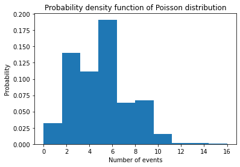

```python
import numpy as np
import matplotlib.pyplot as plt
sn = np.random.poisson(5,1000)   #np.random.poisson(lam=1.0, size=None)
plt.hist(sn,10, density= True)
plt.title("Probability density function of Poisson distribution")
plt.ylabel("Probability")
plt.xlabel("Number of events")
plt.show()
```

#### 20.Write a program to implement linear regression using python.

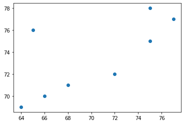

```
slope of the line is 0.46321525885558584
intercept of the line is 40.95912806539509
```

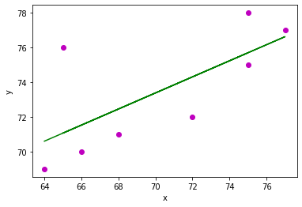

```
Predicted values are : [70.60490463 71.53133515 72.45776567 74.3106267  75.70027248 71.06811989
 76.626703   75.70027248]
```

```python
import numpy as np
import matplotlib.pyplot as plt
#line of the form y =mx+b
def draw_line(x,y,b,m):
    plt.scatter(x, y, color = "m", marker = "o")
    y_pred = b + m*x
    plt.plot(x,y_pred, color = 'g')
    plt.xlabel('x')
    plt.ylabel('y')
    plt.show()
def predict(x):
    y_pred = b + m*x
    print("Predicted values are :",y_pred)
x = np.array([64,66,68,72,75,65,77,75])
y = np.array([69,70,71,72,75,76,77,78])
plt.scatter(x,y)
plt.show()
n = len(x)
mean_x = np.mean(x)
mean_y = np.mean(y)
dev_xy = np.sum(y*x) - n*mean_x*mean_y
dev_xx = np.sum(x*x) - n*mean_x*mean_x
m = dev_xy/dev_xx
print("slope of the line is {}".format(m))
b = mean_y - m*mean_x
print("intercept of the line is {}".format(b))
draw_line(x,y,b,m)
predict(x)
```

#### Q21. Write a program to perform read and write operation with .csv file.

```python
import csv
#READING A CSV FILE
with open("/Users/Medni/Downloads/customerdata.csv","r") as csv_file:
    csv_reader=csv.reader(csv_file)
    for line in csv_reader:
        print(line)
#WRITING IN A CSV FILE
with open("/Users/Medni/Downloads/customerdata.csv","r") as csv_file:
    csv_reader=csv.reader(csv_file)
    with open("/Users/Medni/Desktop/newcustomerdata.csv","w")as new_file:
        csv_writer=csv.writer(new_file,delimiter="\t")
        for line in csv_reader:
            csv_writer.writerow(line)
```

```
['CustomerId', 'Surname', 'CreditScore', 'Geography', 'Gender', 'Age', 'Tenure', 'Balance', 'NumOfProducts', 'HasCrCard', 'IsActiveMember', 'EstimatedSalary', 'Exited', 'Internet Service']
['15634602', 'Hargrave', '619', 'France', 'Female', '42', '2', '0', '1', '1', '1', '101348.88', '1', 'Fiber optic']
['15647311', 'Hill', '608', 'Spain', 'Female', '41', '1', '83807.86', '1', '0', '1', '112542.58', '0', 'DSL']
['15619304', 'Onio', '502', 'France', 'Female', '42', '8', '159660.8', '3', '1', '0', '113931.57', '1', 'Fiber optic']
['15701354', 'Boni', '699', 'France', 'Female', '39', '1', '0', '2', '0', '0', '93826.63', '0', 'DSL']
['15737888', 'Mitchell', '850', 'Spain', 'Female', '43', '2', '125510.82', '1', '1', '1', '79084.1', '0', 'Fiber optic']
['15574012', 'Chu', '645', 'Spain', 'Male', '44', '8', '113755.78', '2', '1', '0', '149756.71', '1', 'DSL']
['15592531', 'Bartlett', '822', 'France', 'Male', '54', '7', '0', '2', '1', '1', '10062.8', '0', 'DSL']
['15656148', 'Obinna', '376', 'Germany', 'Female', '29', '4', '115046.74', '4', '1', '0', '119346.88', '1', 'Fiber optic']
['15792365', 'He', '501', 'France', 'Male', '44', '4', '142051.07', '2', '0', '1', '74940.5', '0', 'DSL']
['15592389', 'H?', '684', 'France', 'Male', '27', '2', '134603.88', '1', '1', '1', '71725.73', '0', 'No']
['15767821', 'Bearce', '528', 'France', 'Male', '31', '5', '102016.72', '2', '0', '0', '80181.12', '0', 'No']
['15737173', 'Andrews', '497', 'Spain', 'Male', '24', '3', '0', '2', '1', '0', '76390.01', '0', 'No']
['15632264', 'Kay', '476', 'France', 'Female', '34', '10', '0', '2', '1', '0', '26260.98', '0', 'Fiber optic']
['15691483', 'Chin', '549', 'France', 'Female', '55', '5', '0', '2', '0', '0', '190857.79', '0', 'No']
```

#### Q22.Write a Program to enter multiple values-based data in multiple columns/rows and show that data in python using DataFrames and pandas.

```python
import pandas as pd

data = {'Names' :['Medni','Nandi','Kanu','Sonu'],
       'Age':[45,56,87,65]}

#Dataframe
info= pd.DataFrame(data)

#print
print(info)
```

```
   Names  Age
0  Medni   45
1  Nandi   56
2   Kanu   87
3   Sonu   65
```

#### Q 23.WAP in python to perform various statistical measures using pandas.

```python
import pandas as pd
data={'Name':["Medni","Nandini","Yashna","Esha","Kanupriya"],
      'Age':[21,20,25,23,24],'Salary':[59990,60005,55643,89222,77789],
      'Occupation':["Operations","Cyber crime ","Fianancial analyst","Teacher","Lawyer"]}
df=pd.DataFrame(data)
print(df)
print(df.describe())
```

```
        Name  Age  Salary          Occupation
0      Medni   21   59990          Operations
1    Nandini   20   60005        Cyber crime
2     Yashna   25   55643  Fianancial analyst
3       Esha   23   89222             Teacher
4  Kanupriya   24   77789              Lawyer
             Age       Salary
count   5.000000      5.00000
mean   22.600000  68529.80000
std     2.073644  14366.36644
min    20.000000  55643.00000
25%    21.000000  59990.00000
50%    23.000000  60005.00000
75%    24.000000  77789.00000
max    25.000000  89222.00000
```

#### Q24.Write a program to plot a bar chart in python to display the result of a school for five consecutive years.

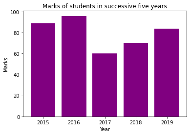

```python
import matplotlib.pyplot as plt
Result_in_percentage=[89,96,60,70,84]
Year=['2015','2016','2017','2018','2019']
plt.bar(Year,Result_in_percentage,color='purple')
plt.xlabel("Year")
plt.ylabel("Marks")
plt.title("Marks of students in successive five years")
plt.show()
```

#### Q25.Write a program in python to plot a graph for the function y = x^2.

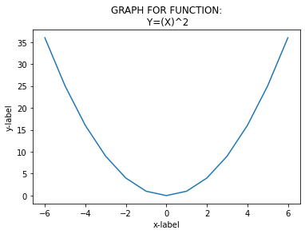

```python
import matplotlib.pyplot as plt
import numpy as np
x=np.arange(-6,7)
y=np.square(x)
plt.xlabel('x-label')
plt.ylabel('y-label')
plt.plot(x,y)
plt.title("GRAPH FOR FUNCTION:\n Y=(X)^2")
plt.show()
```

#### Q26.Write a program in python to plot a pie chart on consumption of water in daily life.

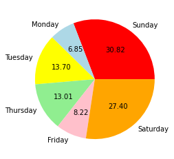

```python
from matplotlib import pyplot as plt
days=['Sunday','Monday','Tuesday','Thursday','Friday','Saturday']
consumption_in_litre = [45,10,20,19,12,40]
color=["red","lightblue","yellow","lightgreen","pink","orange"]
plt.pie(consumption_in_litre,labels=days,colors=color,autopct='%.2f')
plt.show()
```